# Statistical Inference Course Project

Palani

Sunday, June 05, 2016

##### Overview

In this project ,investigating the `exponential distribution` in `R` and compare it with the `Central Limit Theorem`. The exponential distribution simulated in R with rexp(n, lambda) where lambda is the rate parameter. The `mean` of exponential distribution is `1/lambda` and the `standard deviation` is also `1/lambda`. Setting lambda = 0.2 for all of the simulations.And investigate the distribution of averages of 40 exponentials over thousand simulations.

#### Goal

Using simulation ,when the number of samples increases simulated exponential distribution approximates `Norma Distribution`.

##### Task1

**Show the sample mean and compare it to the theoretical mean of the distribution.**

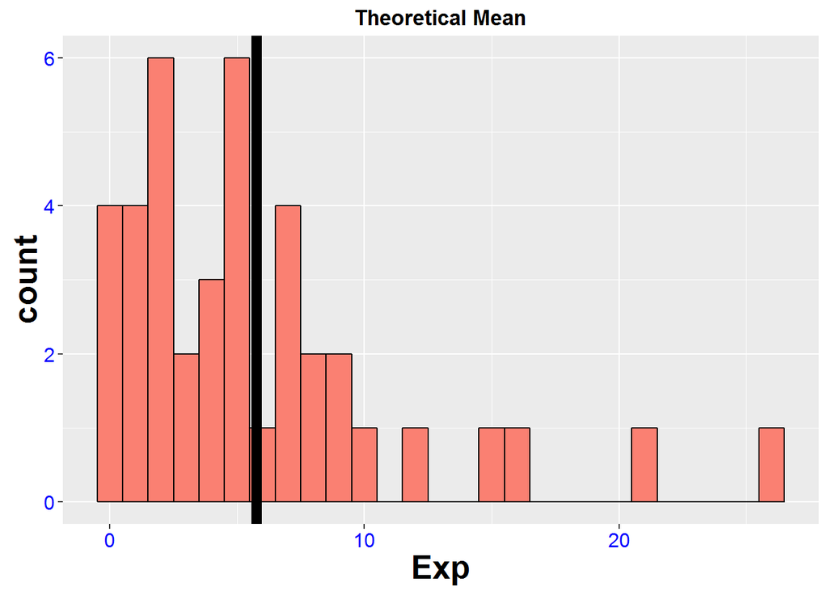

**Distributions of averages of 40 exponentials over 1000 Simulations**

```r
lambda<-0.2
n<-40
nosim <- 1000 #1000 simulations

meanExp<-c() # creating null vector

for (i in 1:nosim){
  lhats <- rexp(n, lambda) #generating exponential distribution
  meanExp[i]<-mean(lhats)  # averaging each simulation
}

#overall mean for the 1000 simulations.
simMean<-mean(meanExp)
simMean
```

```
## [1] 5.007521
```

**Visualising simulated exponential Distribution**

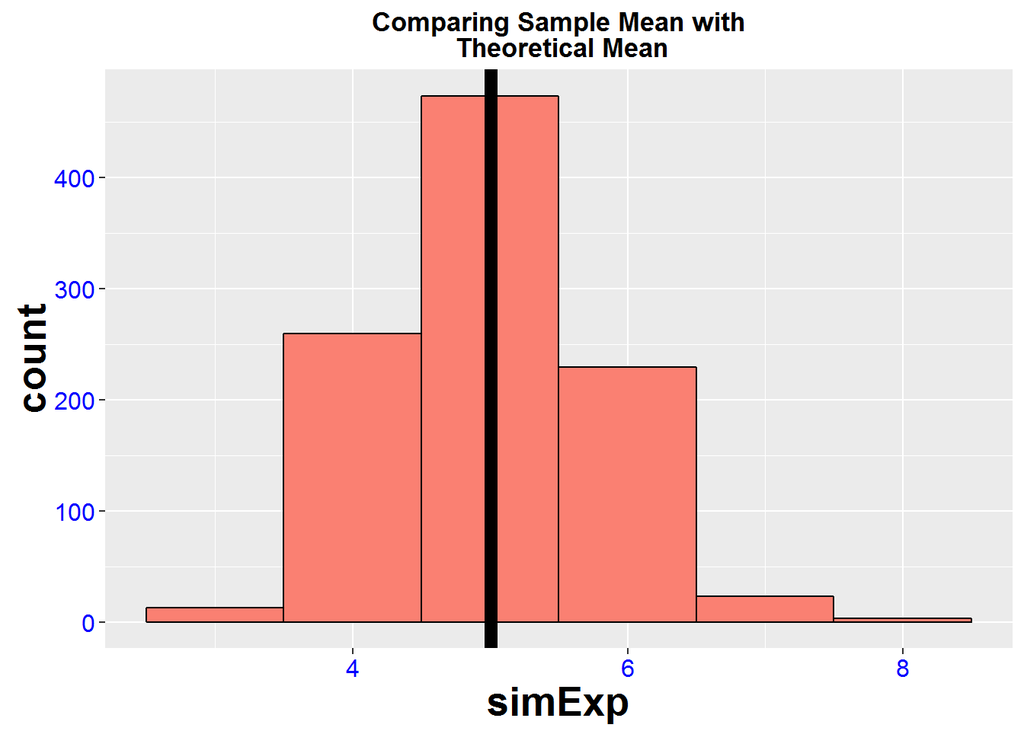

**Inference** `The Law of Large Number` says that sample mean of simulated iid sample is consistent for the `Theoretical Mean`.

##### Task2

**Show how variable the sample is (via variance) and compare it to the theoretical variance of the distribution.**

The simulated variance of exponential is

```r
simVar<-var(meanExp)
simVar
```

[output not shown]

And the theoretical variance is

```r
theryVar<-1/(lambda)^2/n
theryVar
```

```
## [1] 0.625
```

**Inference**  
The result shows that the variance of `Simulated exponential Distribution` approximates the variance of `Theoretical Distribution`.

##### Task3

**Show that the distribution is approximately normal.**

The `density` plot of normal curve shows that the disribution is approximately `Normal`.

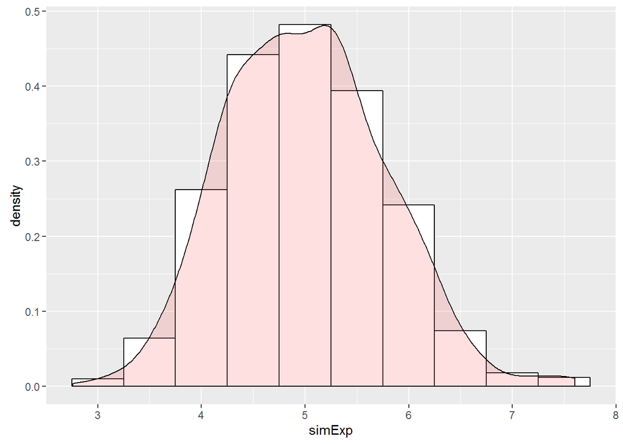

*Normal Probablity Plot*

The plot shows that the distributions are close to diagonal ,again this plot confirma the simulated distribution approximates `Normal`.

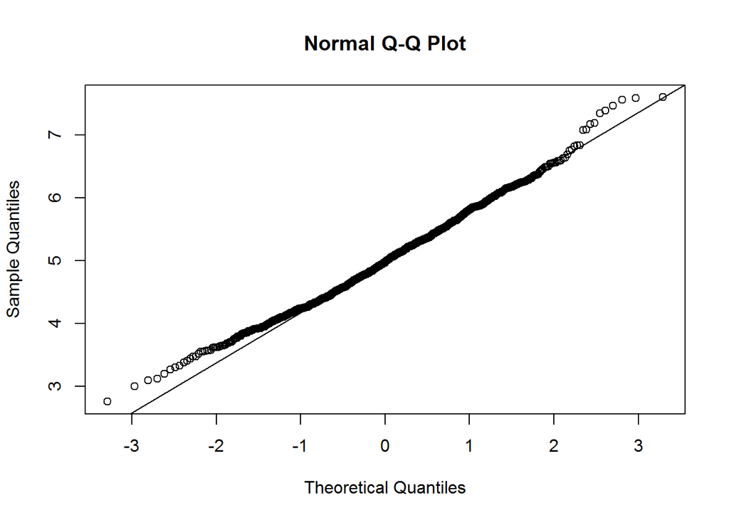

```r
qqnorm(meanExp$simExp)
qqline(meanExp$simExp)
```

**Inference** The above two plots confirms normality.

###### Appendix- Rcode

```r
library(ggplot2)
n<-40
lambda<-0.2
l1<-rexp(n, lambda)
l1<-as.data.frame(l1)
names(l1)<-c('Exp')

g <- ggplot(l1, aes(x = Exp)) + geom_histogram(fill = "salmon", colour = "black", binwidth=1)
g <- g + geom_vline(xintercept = mean(l1$Exp), size = 3)
g+ggtitle("Theoretical Mean")+theme(axis.text = element_text(colour = "blue"))+
  theme(axis.text=element_text(size=12),axis.title=element_text(size=20,face="bold"))+
  theme(plot.title = element_text(lineheight=.8, face="bold"))
```

```r
meanExp<-as.data.frame(meanExp)
names(meanExp)<-c('simExp')
library(ggplot2)
g <- ggplot(meanExp, aes(x = simExp)) + geom_histogram(fill = "salmon", colour = "black", binwidth=1)
g <- g + geom_vline(xintercept = mean(meanExp$simExp), size = 3)
g+ggtitle("Comparing Sample Mean with\n Theoretical Mean")+theme(axis.text = element_text(colour ="blue"))+theme(axis.text=element_text(size=12),axis.title=element_text(size=20,face="bold"))+
theme(plot.title = element_text(lineheight=.8, face="bold"))
```

```r
library(ggplot2)
ggplot(meanExp, aes(x=simExp)) +
  geom_histogram(aes(y=..density..),      # Histogram with density instead of count on y-axis
                 binwidth=.5,
                 colour="black", fill="white") +
  geom_density(alpha=.2, fill="#FF6666")  # Overlay with transparent density plot
```